# Bootstrap analysis: Determine Top Performers - Task1

Sage CNB Team

2025-11-12

## Introduction & Goal 🎯

This notebook outlines the methodology for declaring top-performing methods in the [SEA-AD DREAM Challenge](https://www.synapse.org/sea_ad_dream), specifically by assessing for “tied” performance between submissions.

### Task 1 Evaluation Overview

The primary metric used to evaluate submissions for Task 1 is the Quadratic Weighted Kappa (`QWK`), computed on the predicted overall AD Neuropathological Change (ADNC) scores.

### Methodology

To determine if methods are substantially different in performance, we employ a bootstrapping approach combined with a Bayes Factor ($\text{BF}$) calculation. This statistical framework allows us to assess the statistical equivalence of models across many resampled datasets.

1. **Bootstrapping:** repeatedly sample with replacement (e.g. 1,000 - 10,000 times) the submitted predictions and the groundtruth values. This generates a distribution of performance scores for each participant under various data scenarios.
2. **Bayes Factor (BF):** calculate the BF for each method relative to the top- performing reference method. The BF quantifies the evidence of one model being better than another.

### Determining the Top-Performer(s)

A smaller BF indicates more similar performance. We use a BF cut-off of 3 to define a tie. Any method with a $\text{BF} \le 3$ (relative to the best method) is considered not substantially different and is therefore declared a top-performer alongside the reference method.

## Setup and Data Loading 🛠

### Packages

```r
suppressPackageStartupMessages(library(ggplot2))
suppressPackageStartupMessages(library(dplyr))
suppressPackageStartupMessages(library(knitr))
suppressPackageStartupMessages(library(synapser))

# Login to Synapse.
syn$login(silent=TRUE)
```

### Helper Functions

In addition to importing the scoring functions provided by the challenge organizers, we also define two functions for data processing and analysis:

1. `get_name()`: this function resolves a Synapse `submitterid` (which can be a userID or teamID) into a human-readable username or team name. This will later help with plotting.
2. `computeBayesFactor()`: this function is an updated implementation of the BF calculation, superseding the outdated version in the `challengescoring` package. It calculates the BF for all submissions relative to a specified reference prediction index (`refPredIndex`).

```r
reticulate::source_python("../evaluation/dream_evaluation.py")

get_name <- function(id) {
  name <- tryCatch({
    syn$getUserProfile(id)$userName
  }, error = function(err) {
    syn$getTeam(id)$name
  })
  name
}

computeBayesFactor <- function(bootstrapMetricMatrix,
                               refPredIndex,
                               invertBayes) {
  M <- as.data.frame(bootstrapMetricMatrix - bootstrapMetricMatrix[,refPredIndex])
  K <- apply(M ,2, function(x) {
    k <- sum(x >= 0)/sum(x < 0)

    # Logic handles whether reference column is the best set of predictions.
    if(sum(x >= 0) > sum(x < 0)){
      return(k)
    }else{
      return(1/k)
    }
  })
  K[refPredIndex] <- 0
  if(invertBayes == T){K <- 1/K}
  return(K)
}
```

### Data Acquisition

The Final Round prediction files and the corresponding groundtruth file are retrieved from Synapse, where they are currently stored.

Task 1 Final Round Leaderboard (as seen on Synapse)

| id | submitterid | ADNC_QWK |
| --- | --- | --- |
| 9761204 | gisl7 | 1.0000000 |
| 9761304 | CMC-TJU | 0.9786600 |
| 9761281 | BioICAR | 0.9321410 |
| 9761133 | Metformin-121 | 0.7550492 |
| 9761109 | raesalves | 0.6236629 |
| 9761137 | TeamGeckoAD | 0.4976991 |
| 9760854 | nkck | 0.4951076 |
| 9761319 | ADMIL | 0.4418484 |
| 9761235 | christina.hshi | 0.3883122 |
| 9761311 | Mount_Sinai_Team | 0.2647668 |
| 9761249 | danielr | 0.2039113 |
| 9761232 | TREATS | 0.0754129 |

## Bootstrapping Procedure 📊

First, we combine all individual submission predictions on ADNC and the groundtruth values into a single dataframe. This single source will help create a more efficient resampling process for the bootstrapping analysis.

Preview of Model Predictions and Corresponding Groundtruth Values

| donor_id | gisl7 | CMC-TJU | BioICAR | Metformin-121 | raesalves | TeamGeckoAD | nkck | ADMIL | christina.hshi | Mount_Sinai_Team | danielr | TREATS | truth |
| --- | --- | --- | --- | --- | --- | --- | --- | --- | --- | --- | --- | --- | --- |
| D672 | High | High | High | High | Intermediate | Low | High | Low | High | Low | High | High | High |
| D713 | High | High | High | High | High | Intermediate | High | Low | Intermediate | Low | Low | High | High |
| D632 | High | High | High | High | High | Intermediate | Not AD | High | High | Intermediate | High | High | High |
| D823 | Low | Low | Low | Low | Low | Intermediate | Low | Not AD | Intermediate | High | Intermediate | High | Low |
| D810 | Intermediate | Intermediate | Intermediate | Intermediate | Intermediate | Low | Intermediate | Intermediate | Intermediate | Low | High | High | Intermediate |
| D880 | High | High | High | High | Intermediate | Intermediate | High | Low | Intermediate | High | High | High | High |

Next, we perform a pre-bootstrapping verification to ensure the bootstrapping logic correctly reproduces the published Final Round scores *prior* to any resampling. This serves as a critical check on the bootstrapping and scoring functions.

```r
bs.check <- sapply(names(pred_filenames), function(team) {
  apply(matrix(1:nrow(truth), nrow(truth), 1), 2, function(ind) {
    cohen_kappa_score(
      submissions$truth[ind],
      submissions[[team]][ind],
      weights="quadratic"
    )
  })
})
```

Comparison of “Bootstrapped” Scores (Prior to Resampling) and Original Scores

| submitterid | bf_calculated_score | original_score | scores_match |
| --- | --- | --- | --- |
| gisl7 | 1.0000000 | 1.0000000 | TRUE |
| CMC-TJU | 0.9786600 | 0.9786600 | TRUE |
| BioICAR | 0.9321410 | 0.9321410 | TRUE |
| Metformin-121 | 0.7550492 | 0.7550492 | TRUE |
| raesalves | 0.6236629 | 0.6236629 | TRUE |
| TeamGeckoAD | 0.4976991 | 0.4976991 | TRUE |
| nkck | 0.4951076 | 0.4951076 | TRUE |
| ADMIL | 0.4418484 | 0.4418484 | TRUE |
| christina.hshi | 0.3883122 | 0.3883122 | TRUE |
| Mount_Sinai_Team | 0.2647668 | 0.2647668 | TRUE |
| danielr | 0.2039113 | 0.2039113 | TRUE |
| TREATS | 0.0754129 | 0.0754129 | TRUE |

The core bootstrapping process is then executed:

- Resample the rows (data points) of the combined dataframe 10,000 times ($N=10,000$) with replacement
- For each of the $N$ bootstrap samples, we re-score every submission using the primary challenge metric (Quadratic Weighted Kappa, `QWK`) on ADNC

This will produce a matrix of 10,000 bootstrapped scores per submission.

```r
# Set seed for reproducible results (since we're doing a random sample)
set.seed(202511)

# Run bootstrapping.
N <- 10000
bs_indices <- matrix(1:nrow(truth), nrow(truth), N) %>%
  apply(2, sample, replace = TRUE)

bs <- sapply(names(pred_filenames), function(team) {
  apply(bs_indices, 2, function(ind) {
    cohen_kappa_score(
      submissions$truth[ind],
      submissions[[team]][ind],
      weights="quadratic"
    )
  })
})
```

## Bayes Factor Calculation 📈

The resulting $10,000 \times \text{number of submissions}$ matrix of bootstrapped scores is used to calculate the BF for each submission.

The top-performing model (highest `ADNC_QWK` score) is automatically set as the reference prediction ($BF=0$) against which all other methods are compared.

As established earlier, a $\text{BF} \le 3$ indicates that a method’s performance is not substantially different from the top performer.

| submission | bayes |
| --- | --- |
| gisl7 | 0.000000 |
| CMC-TJU | 7.025682 |
| BioICAR | 22.419204 |
| Metformin-121 | 2499.000000 |
| raesalves | Inf |
| TeamGeckoAD | Inf |
| nkck | Inf |
| ADMIL | Inf |
| christina.hshi | Inf |
| Mount_Sinai_Team | Inf |
| danielr | Inf |
| TREATS | Inf |

## Results & Top Performer Determination 🏆

Methods falling into the “$\text{BF} \le 3$” category, including the top performer ($BF=0$), will be declared “Top Performers” for this challenge task.

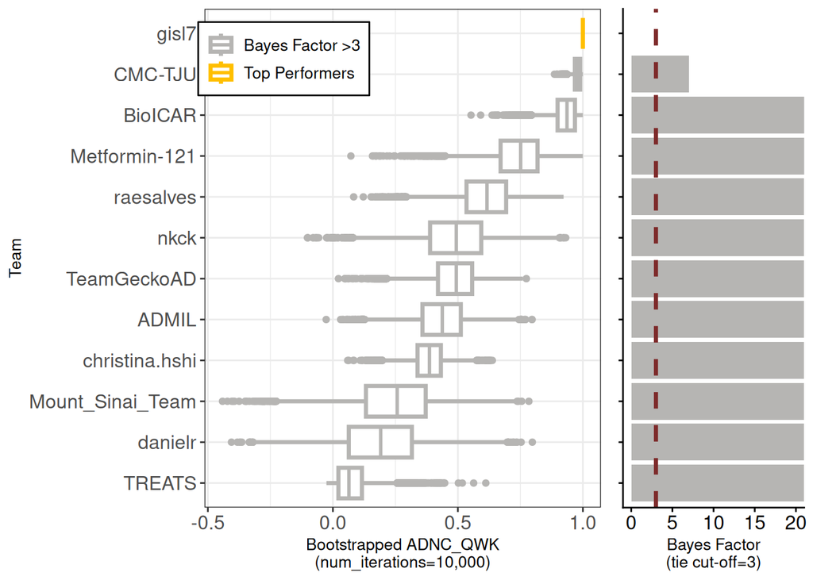

## Conclusion ✨

The objective of this analysis was to use the Bayes factor to identify submissions that are statistically indistinguishable from the overall top performer, using a threshold of $\text{BF} \le 3$ to define a tie.

The analysis confirms that the reference submission, Team gisl7 ($\text{BF}=0$), is the only team whose performance is not substantially different from itself. Since no other submissions yielded a Bayes factor $\le 3$, **team gisl7 is declared the sole “Top Performer” for Task 1 of the SEA-AD DREAM Challenge**.